# Data science per psicologi - demo 11.04

Corrado Caudek

2022-03-22

```r
suppressPackageStartupMessages({
  library("here")
  library("tidyverse")
  library("scales")
  library("bayesplot")
  library("prob")
  library("distrEx")
})

theme_set(bayesplot::theme_default(base_size = 12))
bayesplot::color_scheme_set("gray")
set.seed(84735)

knitr::opts_chunk$set(
  collapse = TRUE,
  tidy = 'styler',
  fig.width = 6,
  fig.asp = 0.618 # 1 / phi
)
```

# Proprietà della covarianza

Consideriamo le proprietà della covarianza delle variabili casuali esaminando, per analogia, le stesse proprietà quando le variabili vengono osservate in un campione di dati. Ricordiamo che le variabili casuali sono ignote prima dell’esecuzione dell’esperimento casuale. Una volta svolto l’esperimento casuale, le variabili casuali sono semplicemente un campione di osservazioni. Ovviamente, la nozione di variabile casuale fa riferimento a tutti i possibili campioni che si possono osservare. Ma per semplicità, qui ne consideriamo uno soltanto.

Generiamo dei dati a caso per due variabili che chiamiamo $X$ e $Y$:

```r
set.seed(123)
n <- 20
x <- rnorm(n, 20, 3)
y <- x + rnorm(n, 0, 2)
```

Le due variabili sono associate:

```r
cor(x, y)
```

```
## [1] 0.858391
```

Un diagramma a dispersione si genera nel modo seguente:

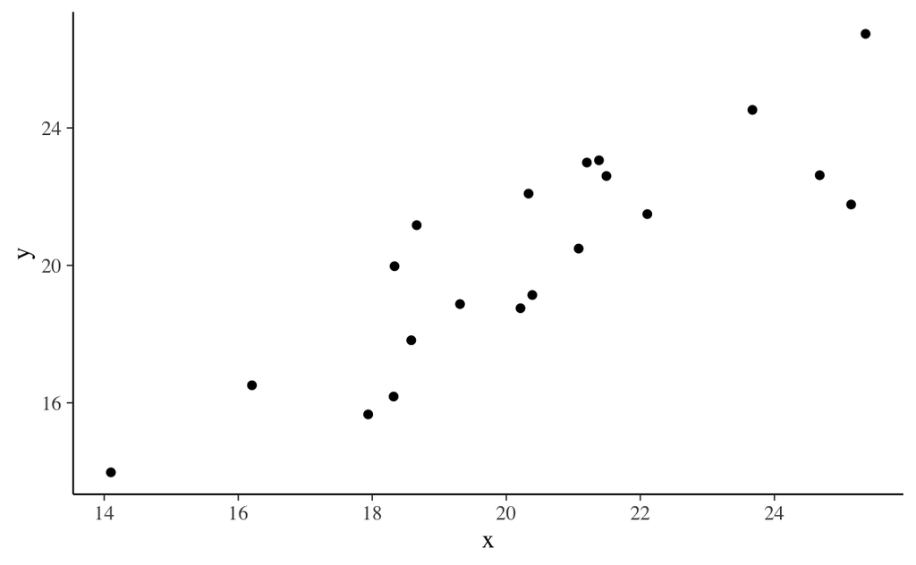

```r
tibble(x, y) %>%
  ggplot(aes(x, y)) +
  geom_point()
```

Esaminiamo le proprietà della covarianza discusse nel capitolo 11 della dispensa.

## Varianza: la covarianza di una variabile con se stessa

Il modo più semplice per ricordare che cos’è la covarianza è di pensare alla varianza come alla covarianza di una variabile con se stessa:

$$\sigma_{xx} = \sum_i \big(x_i - \mathbb{E}(x)\big)\big(x_i -
\mathbb{E}(x)\big) \cdot p_i(x)$$
ovvero

```r
var(x)
```

```
## [1] 8.5147
```

```r
cov(x, x)
```

```
## [1] 8.5147
```

## La covarianza tra una variabile aleatoria 𝑋 e una costante 𝑐 è nulla

```r
cov(rep(3, n), x)
```

```
## [1] 0
```

## La covarianza è simmetrica

```r
cov(x, y) == cov(y, x)
```

```
## [1] TRUE
```

## La correlazione non dipende dall’unità di misura

```r
cor(x, y)
```

```
## [1] 0.858391
```

```r
cor(x * 100, y * 3)
```

```
## [1] 0.858391
```

## Covarianza tra 𝑋 e 𝑌, ciascuna moltiplicata per una costante

Moltiplichiamo $X$ per 3 e $Y$ per 2 e calcoliamo la nuova covarianza:

```r
cov(x, y)
```

```
## [1] 8.07044
```

```r
cov(3 * x, 2 * y)
```

```
## [1] 48.42264
```

```r
6 * cov(x, y)
```

```
## [1] 48.42264
```

## La varianza di una somma

Sommiamo $X$ e $Y$ e calcoliamo la varianza:

```r
z <- x + y
z
```

```
##  [1] 34.50150 38.18299 47.30024 38.96527 39.52565 46.91700 44.44107 32.71638
##  [9] 33.60261 39.83366 48.19742 41.56874 44.19488 42.42036 38.30812 52.09876
## [17] 44.09494 28.07647 43.59621 36.40231
```

La varianza di $Z$ è

```r
var(z)
```

```
## [1] 35.03695
```

ovvero

```r
var(x) + var(y) + 2 * cov(x, y)
```

```
## [1] 35.03695
```

Consideriamo 3 variabili:

```r
w <- y + rnorm(n, 0, 4)
```

Esaminiamo la matrice di correlazioni:

```r
cor(cbind(x, y, w)) %>%
  round(2)
```

```
##      x    y    w
## x 1.00 0.86 0.47
## y 0.86 1.00 0.62
## w 0.47 0.62 1.00
```

```r
t <- x + y + w
t
```

```
##  [1] 47.90560 56.22483 64.86277 66.39483 63.49528 64.19638 65.88785 47.36132
##  [9] 52.38564 60.67083 73.73587 61.94385 67.01596 69.98309 57.38067 84.90266
## [17] 60.50131 44.39125 65.58377 55.08676
```

Calcoliamo la varianza di $T$:

```r
var(t)
```

```
## [1] 91.08093
```

ovvero

```r
var(x) + var(y) + var(w) + 2 * cov(x, y) + 2 * cov(x, w) + 2 * cov(w, y)
```

```
## [1] 91.08093
```

## Conclusione

Si noti che, in tutte le dimostrazioni prevedenti, ho usato le funzioni di $\mathsf{R}$ `var()` e `cov()`, le quali hanno $n-1$ al denominatore. Se facciamo riferimento alle variabili casuali e alla varianza e alla covarianza delle variabili casuali, NON bisogna usare $n-1$ al denominatore. In questo demo ho usato le funzioni `var()` e `cov()` solo per semplicità, per illustrare la logica che sta alla base delle proprietà della varianza e della covarianza delle variabili casuali. Se vogliamo i risultati numerici esatti, dobbiamo, per gli esempi presenti, usare $n$ al denominatore delle formule della varianza e della covarianza.